# R Markdownで作るベタな資料

zombie, uncorrelated

2022/11/01

# 1 はじめに

- html_documentでの利用を前提
- 調べるのが手間かも知れないところをまとめる
  - マークダウン記法自体の話はネット上に大量に資料がある
  - CSSまわりの話はR Markdownのバージョンが上がればバッドノウハウになる可能性大
- 日本に3人ぐらいエヴァンジェリストがいて便利なパッケージを紹介しているが、ベタな扱い方を模索
- [R Markdown Cheat Sheet](https://raw.githubusercontent.com/rstudio/cheatsheets/main/translations/japanese/rmarkdown_ja.pdf)に書いてある話もある
- [R Markdown: The Definitive Guide](https://bookdown.org/yihui/rmarkdown/)に大まかなknow-howはある

# 2 文字入力

- HTMLのタグとタグの間は、HTMLとして解釈される
  - 「強敵（トモ）」と入力するには、<ruby>強敵<rp>（</rp><rt>トモ</rt><rp>）</rp></ruby>
- 特殊文字の入力もHTMLと同様に行なえる
  - 「✓ ♨ ♡ ⚑ ① ② ③」と入力するには、&#10003; &#x2668; &#x2661; &#9873; &#x2460; &#x2461; &#x2462;
- エスケープはC言語の文字列などと同様
  - 文字の前に\を書くとエスケープできて、特殊文字もそのまま表示できる。

# 3 脚注

脚注番号として [^数字] を文に挟み、本文中のどこかに [^数字]: 説明 を書いておくと、文章の末尾に脚注が付記される。 例えば、

```
十分原理と弱い条件付け原理を受け入れる者は，尤度原理[^1]を受け入れることになる．

[^1]: 次のような主張である．パラーメーターθの推論において，データxが観察されたあと，すべての関係する実験情報は観測されたxによる尤度関数の中にある．さらに，相互に比例した2つの尤度関数は，θに関して同じ情報を持つ。
```

と書けばよい。

# 4 TeX形式の数式の入力

$x^2$と$で挟むとインラインで$x^2$と表示できる。 $x=`r sum(1:10)`$とインラインコードを数式内に挿入すると、$x=55$と計算され表示される。

```
$$
y = C_1 e^{-\frac{k}{2} t} \cos{ \Bigg ( t \sqrt{ \omega^2 - \frac{k^2}{4}} \Bigg )} +
C_2 e^{-\frac{k}{2}t} \sin{ \Bigg ( t \sqrt{ \omega^2 - \frac{k^2}{4}} \Bigg ) }
$$
```

とブロック要素で書くと、

$$y = C_1 e^{-\frac{k}{2} t} \cos{ \Bigg ( t \sqrt{ \omega^2 -
\frac{k^2}{4}} \Bigg )} + C_2 e^{-\frac{k}{2}t} \sin{ \Bigg ( t \sqrt{
\omega^2 - \frac{k^2}{4}} \Bigg ) }$$

と表示できる。

# 5 ブロック引用

エスケープ処理が煩雑なので、htmlの<pre></pre>でくくるのが手っ取り早い。

# 6 code chunkの表示関係のオプション

以下を覚えておくと、だいたい困らない。

| コード・ブロックの開始 | 実行 | コード | 出力 | 警告 | メッセージ | ^## |
| --- | --- | --- | --- | --- | --- | --- |
| ```{r} | ✓ | ✓ | ✓ | ✓ | ✓ | ✓ |
| ```{r result=“asis” } | ✓ | ✓ | ✓ | ✓ | ✓ |  |
| ```{r include=FALSE} | ✓ | ✓ |  | ✓ | ✓ | ✓ |
| ```{r eval=FALSE} |  | ✓ |  |  |  |  |
| ```{r echo=FALSE, include=FALSE, warning=FALSE, message=FALSE} | ✓ |  |  |  |  | ✓ |

# 7 表を描く

## 7.1 べた書き

```
|  x  |  y  |  z  |
| :---: | :---: | :---: |
|  `r x[1]`  |  `r y[1]`  |  `r z[1]`  |
|  `r x[2]`  |  `r y[2]`  |  `r z[2]`  |
|  `r x[3]`  |  `r y[3]`  |  `r z[3]`  |
```

以上のようなコードでパイプ表をつくることもできる。:—が左寄せ、—:が右寄せ、:—:が中央寄せ。

| x | y | z |
| --- | --- | --- |
| 0.66074 | 1.02858 | 0.55496 |
| 0.99518 | 1.05014 | 0.82197 |
| 0.47273 | 2.21232 | 0.0803 |

## 7.2 データフレーム

べたな表示だが、これ間に合うことは多い。

```r
head(df01, 10)
```

```
##            y       x        z
## 1   1.028584 0.66074 0.554959
## 2   1.050142 0.99518 0.821970
## 3   2.212323 0.47273 0.080305
## 4   1.604420 0.37531 0.104179
## 5   0.500199 0.11168 0.100333
## 6   0.059343 0.63886 0.771623
## 7  -0.827864 0.38813 0.905811
## 8  -1.700301 0.38546 0.990739
## 9   1.245919 0.65821 0.541823
## 10  0.223935 0.41972 0.672420
```

## 7.3 knitr::kable

データフレームをパイプ表に変換してくれる。

```r
knitr::kable(head(df01, 5))
```

| y | x | z |
| --- | --- | --- |
| 1.0286 | 0.66074 | 0.55496 |
| 1.0501 | 0.99518 | 0.82197 |
| 2.2123 | 0.47273 | 0.08030 |
| 1.6044 | 0.37531 | 0.10418 |
| 0.5002 | 0.11168 | 0.10033 |

## 7.4 DT::datatable

高機能なデータフレーム表示

```r
DT::datatable(df01, options=list(pageLength=5))
```

|  | y | x | z |
| --- | --- | --- | --- |
| 1 | 1.02858383874274 | 0.660736374091357 | 0.55495939985849 |
| 2 | 1.05014220485087 | 0.995175278745592 | 0.821969670709223 |
| 3 | 2.2123233029211 | 0.472731026588008 | 0.0803049891255796 |
| 4 | 1.60441990263263 | 0.375308554619551 | 0.104178763460368 |
| 5 | 0.500199262025135 | 0.111679624533281 | 0.100332706235349 |
| 6 | 0.0593433335327228 | 0.638857788173482 | 0.771623259410262 |
| 7 | -0.8278637200498 | 0.388129509286955 | 0.905810808762908 |
| 8 | -1.70030137806988 | 0.385456497315317 | 0.990738820750266 |
| 9 | 1.2459190672771 | 0.658208943204954 | 0.541822950122878 |
| 10 | 0.223935387069582 | 0.419715138850734 | 0.672420261893421 |

[output cut: 90 more lines]

# 8 推定結果の表示

stargazerパッケージが使える。しかし、code chunkのオプションにresults=“asis”, warning=FALSE, message=FALSEを忘れると困った表示になる。

```r
r_lm <- lm(y ~ x + z, data=df01)
library(stargazer, quietly = TRUE)
stargazer(r_lm, type="html", out.header=FALSE, suppress.errors=TRUE)
```

|  | *Dependent variable:* |
| --- | --- |
|  | y |
| x | 1.935*** |
|  | (0.187) |
| z | -3.058*** |
|  | (0.180) |
| Constant | 1.039*** |
|  | (0.144) |
| Observations | 100 |
| R<sup>2</sup> | 0.808 |
| Adjusted R<sup>2</sup> | 0.804 |
| Residual Std. Error | 0.513 (df = 97) |
| F Statistic | 203.490*** (df = 2; 97) |
| *Note:* | p<0.1; p<0.05; p<0.01 |

Hlavac, Marek (2022). stargazer: Well-Formatted Regression and Summary Statistics Tables. R package version 5.2.3. https://CRAN.R-project.org/package=stargazer

## 8.1 stargazerパッケージの参照の表示

参照を書いてくれと要請されるので、以下のようにHTMLで書いている。

```
<div style="margintop:12px;">

<span style="fontsize: 75%;">Hlavac, Marek (2022). stargazer:
WellFormatted Regression and Summary Statistics Tables.
R package version 5.2.3. https://CRAN.Rproject.org/package=stargazer</span>

</div>
```

GLMで済む場合はstargazerで作業時間が一気に減るはずなので、有難く書いておこう。

# 9 交差検証（LOOCV）の表示

自動で表が作られない場合、例えば交差検証（LOOCV）は、

```r
library(boot)
frml <- c("y ~ x + z", "y ~ x", "y ~ z")
delta <- matrix(NA, length(frml), 2)
rownames(delta) <- frml
colnames(delta) <- c("raw", "adjusted")
for(i in 1:length(frml)){
    delta[i, ] <- cv.glm(df01, glm(formula(frml[i]), data=df01))$delta
}
```

パイプ表の中にTeXの数式とインラインコードを入れて表にする。

```
|  モデル  |  `r colnames(delta)[1]`  |  `r colnames(delta)[2]`  |
| :--- | ---: | ---: |
|  $y = \beta_0 + \beta_1 x + \beta_2 z + \epsilon$  |  `r delta[1,1]`  |  `r delta[1,2]`  |
|  $y = \beta_0 + \beta_1 x + \epsilon$  |  `r delta[2,1]`  |  `r delta[2,2]`  |
|  $y = \beta_0 + \beta_2 z + \epsilon$  |  `r delta[3,1]`  |  `r delta[3,2]`  |
```

| モデル | raw | adjusted |
| --- | --- | --- |
| $y = \beta_0 + \beta_1 x + \beta_2 z + \epsilon$ | 0.27268 | 0.27259 |
| $y = \beta_0 + \beta_1 x + \epsilon$ | 1.05432 | 1.05411 |
| $y = \beta_0 + \beta_2 z + \epsilon$ | 0.56146 | 0.56135 |

# 10 プロットの表示

code chunkの中にplot命令を入れたらよいだけだが、code chunkのオプションはfig.align=“center”, fig.width=9, fig.heigth=8のようにつけ、Rのコードでもpar(mar=c(4, 4, 0.1, 0.1))などと表示調整した方がよい。

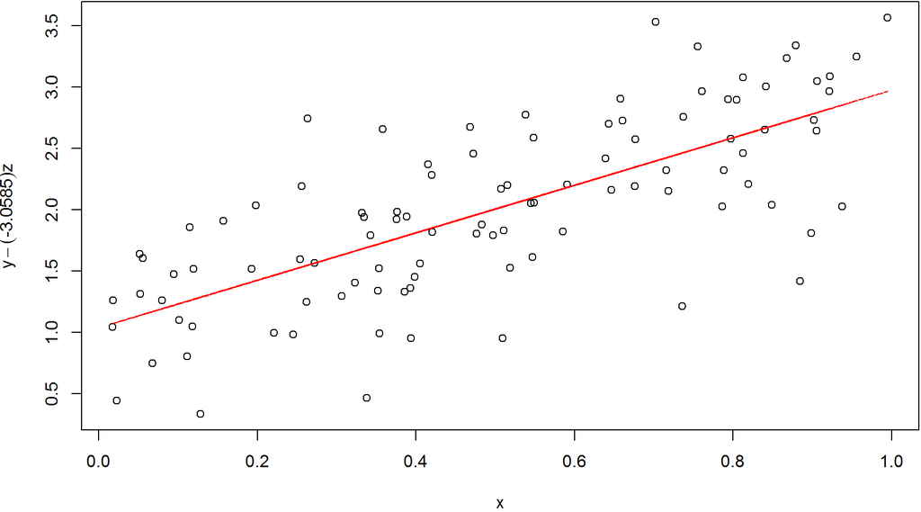

# 11 まとめ

- 頻繁に定型レポートを書く人にはたぶん便利
- rmarkdown::renderでRmdからhtmlを生成できるので自動化もできる
- code chunkにbrowserを埋め込めるのでデバッグもできるが、テスト済みコードを埋めよう